# Soluções: Lista de Exercícios 1

MPA - Discipplina: Introdução à Ciência dos Dados 2022

Prof. Washington S. Silva

26/04/2022

## Questão 1

```r
x <- 10*30
x          # ou
```

```
## [1] 300
```

```r
print(x)
```

```
## [1] 300
```

## Questão 2

```r
?seq
y <- seq(1:100)
length(y)
```

```
## [1] 100
```

## Questão 3

```r
romano <- letters
```

```r
romano <- letters
?LETTERS
```

## Questão 4

```r
ls()
```

```
## [1] "romano" "x"      "y"
```

## Questão 5

```r
rm(romano, x, y)
ls()
```

```
## character(0)
```

## Questão 6

Os principais tipos de dados atômicos da linguagem R são:

- `double`
- `integer`
- `character`
- `logical`
- `complex`

  Há ainda os tipos especiais:
- `NA`
- `NaN`
- `inf`

```r
nome_carro <- 'volvo'
typeof(nome_carro)   # tipo
```

```
## [1] "character"
```

```r
class(nome_carro)    # classe
```

```
## [1] "character"
```

```r
preco <- 200.58
typeof(preco)
```

```
## [1] "double"
```

```r
class(preco)
```

```
## [1] "numeric"
```

```r
feminino <- TRUE
typeof(feminino)
```

```
## [1] "logical"
```

```r
class(feminino)
```

```
## [1] "logical"
```

```r
TRUE*FALSE
```

```
## [1] 0
```

```r
TRUE^7
```

```
## [1] 1
```

O que explica os resultados é o fato do interpretador da linguagem R converter o valor lógico `TRUE` para `1` e `FALSE` para `0` em operações aritméticas.

## Questão 7

```r
fruits <- c("banana", "apple", "orange")
```

```r
length(fruits)
```

```
## [1] 3
```

```r
fruits <- list("banana", "apple", "orange")
fruits
```

```
## [[1]]
## [1] "banana"
##
## [[2]]
## [1] "apple"
##
## [[3]]
## [1] "orange"
```

## Questão 8

```r
fruits <- c("banana", "apple", "orange", "mango", "lemon")
numbers <- c(13, 3, 5, 7, 20, 2)

sort(fruits)
```

```
## [1] "apple"  "banana" "lemon"  "mango"  "orange"
```

```r
sort(numbers)
```

```
## [1]  2  3  5  7 13 20
```

Quando aplicado a um vetor de caracteres, a função `sort()` ordena os valores em ordem alfabética.

## Questão 9

```r
vendas <- c(653, 552, 748, 658, 502, 310, 160)
custo <- c(243, 218, 283, 284, 212, 98, 110)
```

```r
# vendas
class(vendas)
```

```
## [1] "numeric"
```

```r
length(vendas)
```

```
## [1] 7
```

```r
# custo
class(custo)
```

```
## [1] "numeric"
```

```r
length(custo)
```

```
## [1] 7
```

```r
lucro <- vendas - custo
lucro
```

```
## [1] 410 334 465 374 290 212  50
```

Podemos utilizar a função `replace()`

```r
vendas <- replace(vendas, vendas == 310, 130)
lucro <- vendas - custo
lucro
```

```
## [1] 410 334 465 374 290  32  50
```

Ou também com a seguinte sintáxe: `vendas[x == 310] <- 130`

```r
lucro_total <- sum(lucro)
lucro_total
```

```
## [1] 1955
```

```r
lucro_medio_diario <- mean(lucro)
lucro_medio_diario
```

```
## [1] 279.29
```

```r
# por inclusao
lucro_medio_semana <- mean(lucro[1:5])
lucro_medio_semana
```

```
## [1] 374.6
```

```r
# por exclusao
lucro_medio_semana <- mean(lucro[-c(6,7)])
lucro_medio_semana
```

```
## [1] 374.6
```

```r
lucro_medio_fimsemana <- mean(lucro[c(6,7)])
lucro_medio_fimsemana
```

```
## [1] 41
```

## Questão 10

```r
df <-  data.frame(
  Training = c("Strength", "Stamina", "Other"),
  Pulse = c(100, 150, 120),
  Duration = c(60, 30, 45)
)

# verificando se a data.frame foi criada
df
```

```
##   Training Pulse Duration
## 1 Strength   100       60
## 2  Stamina   150       30
## 3    Other   120       45
```

```r
class(df)
```

```
## [1] "data.frame"
```

## Questão 11

```r
musica_genero <- factor(c("Jazz", "Rock", "Classic", "Classic", "Pop", "Jazz", "Rock", "Jazz"))
musica_genero
```

```
## [1] Jazz    Rock    Classic Classic Pop     Jazz    Rock    Jazz
## Levels: Classic Jazz Pop Rock
```

Tecnicamente, o elemento faltante, `factor()`, é uma estrutura de dados da linguagem R que fornce uma forma mais adequada para armazenar e modeloar dados categóricos ou qualitativos, cujo tipo em geral é `character`. s

## Questão 12

```r
# ativando o pacote
library(dplyr)
library(gapminder)

# visulizando a estrutura dos dados
glimpse(gapminder)
```

```
## Rows: 1,704
## Columns: 6
## $ country   <fct> "Afghanistan", "Afghanistan", "Afghanistan", "Afghanistan", …
## $ continent <fct> Asia, Asia, Asia, Asia, Asia, Asia, Asia, Asia, Asia, Asia, …
## $ year      <int> 1952, 1957, 1962, 1967, 1972, 1977, 1982, 1987, 1992, 1997, …
## $ lifeExp   <dbl> 28.801, 30.332, 31.997, 34.020, 36.088, 38.438, 39.854, 40.8…
## $ pop       <int> 8425333, 9240934, 10267083, 11537966, 13079460, 14880372, 12…
## $ gdpPercap <dbl> 779.45, 820.85, 853.10, 836.20, 739.98, 786.11, 978.01, 852.…
```

```r
# filtrando os dados para o Brasil
gapminder %>% filter(country == "Brazil")
```

```
## # A tibble: 12 × 6
##    country continent  year lifeExp       pop gdpPercap
##    <fct>   <fct>     <int>   <dbl>     <int>     <dbl>
##  1 Brazil  Americas   1952    50.9  56602560     2109.
##  2 Brazil  Americas   1957    53.3  65551171     2487.
##  3 Brazil  Americas   1962    55.7  76039390     3337.
##  4 Brazil  Americas   1967    57.6  88049823     3430.
##  5 Brazil  Americas   1972    59.5 100840058     4986.
##  6 Brazil  Americas   1977    61.5 114313951     6660.
##  7 Brazil  Americas   1982    63.3 128962939     7031.
##  8 Brazil  Americas   1987    65.2 142938076     7807.
##  9 Brazil  Americas   1992    67.1 155975974     6950.
## 10 Brazil  Americas   1997    69.4 168546719     7958.
## 11 Brazil  Americas   2002    71.0 179914212     8131.
## 12 Brazil  Americas   2007    72.4 190010647     9066.
```

```r
gapminder %>% filter(lifeExp < 30)
```

```
## # A tibble: 2 × 6
##   country     continent  year lifeExp     pop gdpPercap
##   <fct>       <fct>     <int>   <dbl>   <int>     <dbl>
## 1 Afghanistan Asia       1952    28.8 8425333      779.
## 2 Rwanda      Africa     1992    23.6 7290203      737.
```

```r
filter(gapminder, country == "Rwanda", year > 1979)
```

```
## # A tibble: 6 × 6
##   country continent  year lifeExp     pop gdpPercap
##   <fct>   <fct>     <int>   <dbl>   <int>     <dbl>
## 1 Rwanda  Africa     1982    46.2 5507565      882.
## 2 Rwanda  Africa     1987    44.0 6349365      848.
## 3 Rwanda  Africa     1992    23.6 7290203      737.
## 4 Rwanda  Africa     1997    36.1 7212583      590.
## 5 Rwanda  Africa     2002    43.4 7852401      786.
## 6 Rwanda  Africa     2007    46.2 8860588      863.
```

```r
filter(gapminder, country %in% c("Brazil", "Argentina"))
```

```
## # A tibble: 24 × 6
##    country   continent  year lifeExp      pop gdpPercap
##    <fct>     <fct>     <int>   <dbl>    <int>     <dbl>
##  1 Argentina Americas   1952    62.5 17876956     5911.
##  2 Argentina Americas   1957    64.4 19610538     6857.
##  3 Argentina Americas   1962    65.1 21283783     7133.
##  4 Argentina Americas   1967    65.6 22934225     8053.
##  5 Argentina Americas   1972    67.1 24779799     9443.
##  6 Argentina Americas   1977    68.5 26983828    10079.
##  7 Argentina Americas   1982    69.9 29341374     8998.
##  8 Argentina Americas   1987    70.8 31620918     9140.
##  9 Argentina Americas   1992    71.9 33958947     9308.
## 10 Argentina Americas   1997    73.3 36203463    10967.
## # … with 14 more rows
## # ℹ Use `print(n = ...)` to see more rows
```

```r
gapminder %>% filter(country == "Brazil") %>% select(country, lifeExp, pop, gdpPercap)
```

```
## # A tibble: 12 × 4
##    country lifeExp       pop gdpPercap
##    <fct>     <dbl>     <int>     <dbl>
##  1 Brazil     50.9  56602560     2109.
##  2 Brazil     53.3  65551171     2487.
##  3 Brazil     55.7  76039390     3337.
##  4 Brazil     57.6  88049823     3430.
##  5 Brazil     59.5 100840058     4986.
##  6 Brazil     61.5 114313951     6660.
##  7 Brazil     63.3 128962939     7031.
##  8 Brazil     65.2 142938076     7807.
##  9 Brazil     67.1 155975974     6950.
## 10 Brazil     69.4 168546719     7958.
## 11 Brazil     71.0 179914212     8131.
## 12 Brazil     72.4 190010647     9066.
```

```r
gapminder %>% filter(country == "Brazil", year == 2007) %>% select(country, lifeExp, pop, gdpPercap)
```

```
## # A tibble: 1 × 4
##   country lifeExp       pop gdpPercap
##   <fct>     <dbl>     <int>     <dbl>
## 1 Brazil     72.4 190010647     9066.
```

```r
# gapminder %>% filter(continent == "Americas", country == "Brazil", year %in% c(1997, 2002, 2007))
gapminder %>% filter(country == "Brazil", year %in% c(1997, 2002, 2007))
```

```
## # A tibble: 3 × 6
##   country continent  year lifeExp       pop gdpPercap
##   <fct>   <fct>     <int>   <dbl>     <int>     <dbl>
## 1 Brazil  Americas   1997    69.4 168546719     7958.
## 2 Brazil  Americas   2002    71.0 179914212     8131.
## 3 Brazil  Americas   2007    72.4 190010647     9066.
```

```r
gapminder %>% filter(country == "Brazil", year == 2007) %>% select(lifeExp)
```

```
## # A tibble: 1 × 1
##   lifeExp
##     <dbl>
## 1    72.4
```

```r
gapminder %>% filter(country == "Argentina", year == 2007) %>% select(lifeExp)
```

```
## # A tibble: 1 × 1
##   lifeExp
##     <dbl>
## 1    75.3
```

```r
gapminder %>% filter(year == 2007) %>% group_by(continent) %>% summarise(lifeExp_media = mean(lifeExp))
```

```
## # A tibble: 5 × 2
##   continent lifeExp_media
##   <fct>             <dbl>
## 1 Africa             54.8
## 2 Americas           73.6
## 3 Asia               70.7
## 4 Europe             77.6
## 5 Oceania            80.7
```

```r
gapminder %>% filter(year == 2007) %>% group_by(continent) %>% summarise(pop_total = sum(lifeExp))
```

```
## # A tibble: 5 × 2
##   continent pop_total
##   <fct>         <dbl>
## 1 Africa        2850.
## 2 Americas      1840.
## 3 Asia          2334.
## 4 Europe        2329.
## 5 Oceania        161.
```

```r
gapminder %>% filter(year == 2007) %>% group_by(country) %>% mutate(totalGdp = pop*gdpPercap)
```

```
## # A tibble: 142 × 7
## # Groups:   country [142]
##    country     continent  year lifeExp       pop gdpPercap      totalGdp
##    <fct>       <fct>     <int>   <dbl>     <int>     <dbl>         <dbl>
##  1 Afghanistan Asia       2007    43.8  31889923      975.  31079291949.
##  2 Albania     Europe     2007    76.4   3600523     5937.  21376411360.
##  3 Algeria     Africa     2007    72.3  33333216     6223. 207444851958.
##  4 Angola      Africa     2007    42.7  12420476     4797.  59583895818.
##  5 Argentina   Americas   2007    75.3  40301927    12779. 515033625357.
##  6 Australia   Oceania    2007    81.2  20434176    34435. 703658358894.
##  7 Austria     Europe     2007    79.8   8199783    36126. 296229400691.
##  8 Bahrain     Asia       2007    75.6    708573    29796.  21112675360.
##  9 Bangladesh  Asia       2007    64.1 150448339     1391. 209311822134.
## 10 Belgium     Europe     2007    79.4  10392226    33693. 350141166520.
## # … with 132 more rows
## # ℹ Use `print(n = ...)` to see more rows
```

## Questão 13

```r
gapminder %>%
  filter(year == 2007) %>%
  mutate(percentile = ntile(lifeExp, 100)) %>%
  arrange(desc(gdpPercap)) %>%
  print(n = 142)
```

```
## # A tibble: 142 × 7
##     country                  continent  year lifeExp        pop gdpPer…¹ perce…²
##     <fct>                    <fct>     <int>   <dbl>      <int>    <dbl>   <int>
##   1 Norway                   Europe     2007    80.2    4627926   49357.      88
##   2 Kuwait                   Asia       2007    77.6    2505559   47307.      68
##   3 Singapore                Asia       2007    80.0    4553009   47143.      87
##   4 United States            Americas   2007    78.2  301139947   42952.      71
##   5 Ireland                  Europe     2007    78.9    4109086   40676.      79
##   6 Hong Kong, China         Asia       2007    82.2    6980412   39725.      99
##   7 Switzerland              Europe     2007    81.7    7554661   37506.      97
##   8 Netherlands              Europe     2007    79.8   16570613   36798.      85
##   9 Canada                   Americas   2007    80.7   33390141   36319.      91
##  10 Iceland                  Europe     2007    81.8     301931   36181.      98
##  11 Austria                  Europe     2007    79.8    8199783   36126.      86
##  12 Denmark                  Europe     2007    78.3    5468120   35278.      73
```

[output cut: 131 more lines]

```r
gapminder %>%
  filter(year == 2007) %>%
  mutate(percentile = ntile(lifeExp, 100)) %>%
  arrange(percentile)
```

```
## # A tibble: 142 × 7
##    country                  continent  year lifeExp      pop gdpPercap percent…¹
##    <fct>                    <fct>     <int>   <dbl>    <int>     <dbl>     <int>
##  1 Mozambique               Africa     2007    42.1 19951656      824.         1
##  2 Swaziland                Africa     2007    39.6  1133066     4513.         1
##  3 Sierra Leone             Africa     2007    42.6  6144562      863.         2
##  4 Zambia                   Africa     2007    42.4 11746035     1271.         2
##  5 Angola                   Africa     2007    42.7 12420476     4797.         3
##  6 Lesotho                  Africa     2007    42.6  2012649     1569.         3
##  7 Afghanistan              Asia       2007    43.8 31889923      975.         4
##  8 Zimbabwe                 Africa     2007    43.5 12311143      470.         4
##  9 Central African Republic Africa     2007    44.7  4369038      706.         5
## 10 Liberia                  Africa     2007    45.7  3193942      415.         5
## # … with 132 more rows, and abbreviated variable name ¹percentile
## # ℹ Use `print(n = ...)` to see more rows
```

Sim - a hipótesse parece fazer sentido. Pelos resultados acima, podemos ver que os países classificados em ordem decrescente dp PIB per capita e seus respectivos percentis de expectativa de vida, todos os países estão bem acima da mediana (50º percentil). Além disso, os países com o PIB per capita mais baixo estão localizados perto dos percentis mais baixos.

## Questão 14

```r
gapminder %>%
  filter(year == 2007) %>%
  mutate(percentile = ntile(lifeExp, 100)) %>%
  filter(percentile > 90) %>%
  arrange(desc(percentile)) %>%
  slice_max(percentile, n = 10) %>%
  select(continent, country, lifeExp, percentile)
```

```
## # A tibble: 10 × 4
##    continent country          lifeExp percentile
##    <fct>     <fct>              <dbl>      <int>
##  1 Asia      Japan               82.6        100
##  2 Asia      Hong Kong, China    82.2         99
##  3 Europe    Iceland             81.8         98
##  4 Europe    Switzerland         81.7         97
##  5 Oceania   Australia           81.2         96
##  6 Europe    Spain               80.9         95
##  7 Europe    Sweden              80.9         94
##  8 Asia      Israel              80.7         93
##  9 Europe    France              80.7         92
## 10 Americas  Canada              80.7         91
```

A função `slice_max()` do pacote `dplyr` Selecione as observações/linhas com os valores mais altos de uma variável.

## Questão 15

```r
## Pacotes readxl
library(readxl)
library(tidyverse)

file_xlsx <- "dados_brutos/fundos.xlsx"

fundos <- readxl::read_xlsx(file_xlsx,
                                sheet = "dados",
                                col_types = c("date", "numeric", "numeric",
                                              "numeric", "numeric", "numeric",
                                              "numeric")
                            )
glimpse(fundos)
```

```
## Rows: 16
## Columns: 7
## $ Data     <dttm> 2020-03-01, 2020-04-01, 2020-05-01, 2020-06-01, 2020-07-01, …
## $ MinRisco <dbl> -24.93189, 11.80605, 4.86620, 3.73343, 6.30266, -3.41603, -3.…
## $ MaxIS    <dbl> -29.37968, 20.82486, 8.37441, 10.56813, 13.43251, 0.38733, -2…
## $ Ingênua  <dbl> -34.40987, 14.12346, 7.51150, 11.74111, 6.92984, -3.05557, -5…
## $ IBOV     <dbl> -29.95, 10.60, 8.98, 8.47, 7.88, -3.67, -5.40, -1.53, 14.88, …
## $ IBRA     <dbl> -30.34, 10.49, 8.70, 8.87, 7.89, -3.60, -5.37, -1.43, 14.44, …
## $ CDI      <dbl> 0.33837, 0.28493, 0.23581, 0.21233, 0.19434, 0.15989, 0.15697…
```

```r
class(fundos)
```

```
## [1] "tbl_df"     "tbl"        "data.frame"
```

```r
head(fundos)
```

```
## # A tibble: 6 × 7
##   Data                MinRisco   MaxIS Ingênua   IBOV   IBRA   CDI
##   <dttm>                 <dbl>   <dbl>   <dbl>  <dbl>  <dbl> <dbl>
## 1 2020-03-01 00:00:00   -24.9  -29.4    -34.4  -30.0  -30.3  0.338
## 2 2020-04-01 00:00:00    11.8   20.8     14.1   10.6   10.5  0.285
## 3 2020-05-01 00:00:00     4.87   8.37     7.51   8.98   8.7  0.236
## 4 2020-06-01 00:00:00     3.73  10.6     11.7    8.47   8.87 0.212
## 5 2020-07-01 00:00:00     6.30  13.4      6.93   7.88   7.89 0.194
## 6 2020-08-01 00:00:00    -3.42   0.387   -3.06  -3.67  -3.6  0.160
```

```r
tail(fundos)
```

```
## # A tibble: 6 × 7
##   Data                MinRisco MaxIS Ingênua  IBOV  IBRA   CDI
##   <dttm>                 <dbl> <dbl>   <dbl> <dbl> <dbl> <dbl>
## 1 2021-01-01 00:00:00    -2.32 -3.20  -4.83  -3.56 -3.01 0.149
## 2 2021-02-01 00:00:00     3.83 -1.54  -4.59  -5.19 -4.11 0.135
## 3 2021-03-01 00:00:00    13.1   7.26   6.24   5.02  4.97 0.201
## 4 2021-04-01 00:00:00     7.58  3.10   4.37   1.62  3.07 0.208
## 5 2021-05-01 00:00:00     3.17  6.50   6.28   5.28  4.94 0.270
## 6 2021-06-01 00:00:00    -1.14 -1.63   0.766 -0.07  0.18 0.308
```

```r
fundos <- fundos %>%
  mutate(
         mes = as.Date(Data, format = "%d/%m/%Y"),
            )

glimpse(fundos)
```

```
## Rows: 16
## Columns: 8
## $ Data     <dttm> 2020-03-01, 2020-04-01, 2020-05-01, 2020-06-01, 2020-07-01, …
## $ MinRisco <dbl> -24.93189, 11.80605, 4.86620, 3.73343, 6.30266, -3.41603, -3.…
## $ MaxIS    <dbl> -29.37968, 20.82486, 8.37441, 10.56813, 13.43251, 0.38733, -2…
## $ Ingênua  <dbl> -34.40987, 14.12346, 7.51150, 11.74111, 6.92984, -3.05557, -5…
## $ IBOV     <dbl> -29.95, 10.60, 8.98, 8.47, 7.88, -3.67, -5.40, -1.53, 14.88, …
## $ IBRA     <dbl> -30.34, 10.49, 8.70, 8.87, 7.89, -3.60, -5.37, -1.43, 14.44, …
## $ CDI      <dbl> 0.33837, 0.28493, 0.23581, 0.21233, 0.19434, 0.15989, 0.15697…
## $ mes      <date> 2020-03-01, 2020-04-01, 2020-05-01, 2020-06-01, 2020-07-01, …
```

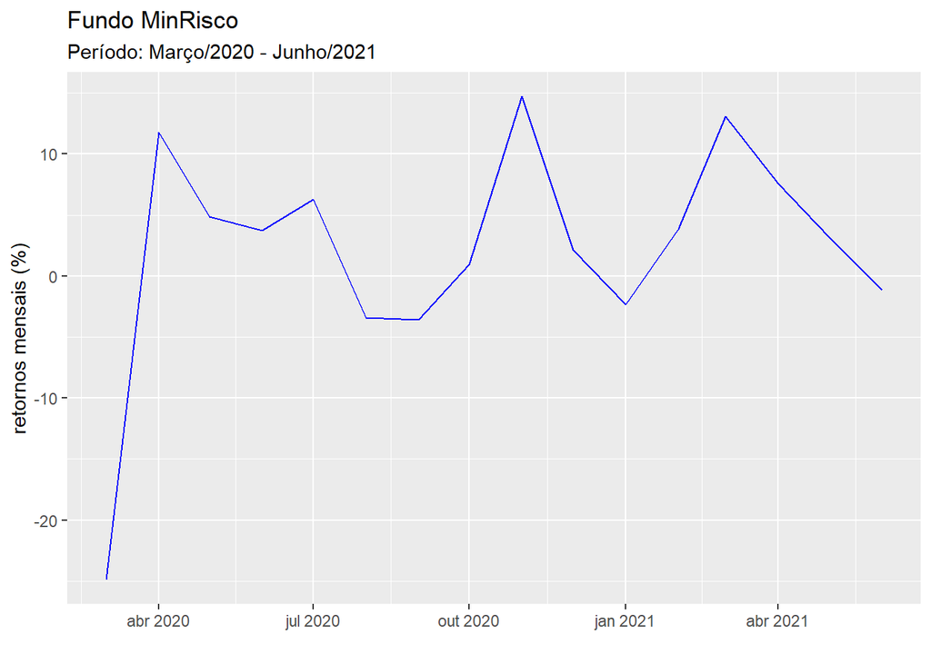

```r
library(ggplot2)

minrisco <- ggplot(fundos, aes(Data, MinRisco)) +
  geom_line(color = 'blue') +
  labs(
    x = " ",
    y = "retornos mensais (%)",
    title = "Fundo MinRisco",
    subtitle = "Período: Março/2020 - Junho/2021"
  )
minrisco
```

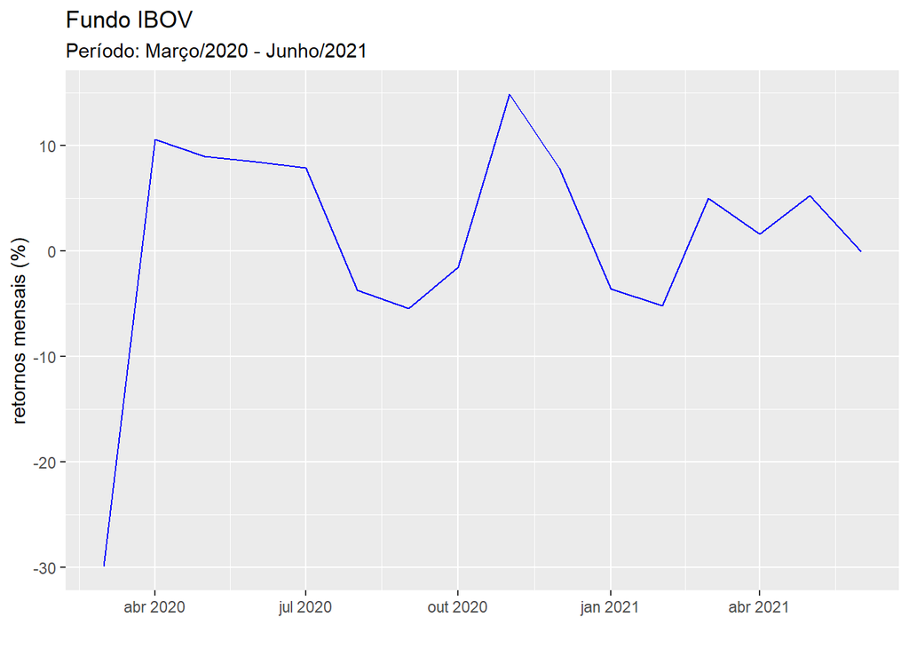

```r
ibov <- ggplot(fundos, aes(Data, IBOV)) +
  geom_line(color = 'blue') +
  labs(
    x = " ",
    y = "retornos mensais (%)",
    title = "Fundo IBOV",
    subtitle = "Período: Março/2020 - Junho/2021"
  )
ibov
```

```r
# usando basicStats() do pacote fBasics
library(fBasics)

fundos_bs <- fundos %>% select(-Data)
basicStats(as.timeSeries(fundos_bs))
```

```
##             MinRisco    MaxIS  Ingênua     IBOV     IBRA       CDI
## nobs         16.0000  16.0000  16.0000  16.0000  16.0000 16.000000
## NAs           0.0000   0.0000   0.0000   0.0000   0.0000  0.000000
## Minimum     -24.9319 -29.3797 -34.4099 -29.9500 -30.3400  0.134532
## Maximum      14.7166  20.8249  14.6150  14.8800  14.4400  0.338370
## 1. Quartile  -1.4352  -1.5644  -3.4386  -3.5875  -3.1575  0.156971
## 3. Quartile   6.6227   8.9228   7.0753   8.0275   8.0925  0.244436
## Mean          2.3029   3.4509   1.4171   1.3250   1.4619  0.207784
## Median        3.4498   4.8031   4.8271   3.3200   4.0050  0.197713
## Sum          36.8458  55.2144  22.6737  21.2000  23.3900  3.324549
## SE Mean       2.2924   2.7708   2.9058   2.5972   2.5894  0.015738
## LCL Mean     -2.5832  -2.4550  -4.7764  -4.2108  -4.0572  0.174240
## UCL Mean      7.1890   9.3568   7.6106   6.8608   6.9810  0.241328
## Variance     84.0804 122.8398 135.0948 107.9277 107.2761  0.003963
## Stdev         9.1695  11.0833  11.6230  10.3888  10.3574  0.062951
## Skewness     -1.3348  -1.2979  -1.6243  -1.4864  -1.6085  0.678140
## Kurtosis      2.3019   2.3074   2.9077   2.4359   2.8188 -0.945844
```

```r
# usando a funcao summary()
summary(fundos)
```

```
##       Data                        MinRisco          MaxIS
##  Min.   :2020-03-01 00:00:00   Min.   :-24.93   Min.   :-29.38
##  1st Qu.:2020-06-23 12:00:00   1st Qu.: -1.44   1st Qu.: -1.56
##  Median :2020-10-16 12:00:00   Median :  3.45   Median :  4.80
##  Mean   :2020-10-16 00:00:00   Mean   :  2.30   Mean   :  3.45
##  3rd Qu.:2021-02-08 00:00:00   3rd Qu.:  6.62   3rd Qu.:  8.92
##  Max.   :2021-06-01 00:00:00   Max.   : 14.72   Max.   : 20.82
##     Ingênua            IBOV             IBRA             CDI
##  Min.   :-34.41   Min.   :-29.95   Min.   :-30.34   Min.   :0.135
##  1st Qu.: -3.44   1st Qu.: -3.59   1st Qu.: -3.16   1st Qu.:0.157
##  Median :  4.83   Median :  3.32   Median :  4.00   Median :0.198
##  Mean   :  1.42   Mean   :  1.32   Mean   :  1.46   Mean   :0.208
##  3rd Qu.:  7.08   3rd Qu.:  8.03   3rd Qu.:  8.09   3rd Qu.:0.244
##  Max.   : 14.62   Max.   : 14.88   Max.   : 14.44   Max.   :0.338
##       mes
##  Min.   :2020-03-01
##  1st Qu.:2020-06-23
##  Median :2020-10-16
##  Mean   :2020-10-16
##  3rd Qu.:2021-02-08
##  Max.   :2021-06-01
```

## Questão 16

```r
# ativando o pacote
library(owidR)

# importando os dados
energia_solar <- owid("solar-energy-consumption-by-region")
dplyr::glimpse(energia_solar)
```

```
## Rows: 4,567
## Columns: 4
## $ entity <chr> "Africa (BP)", "Africa (BP)", "Africa (BP)", "Africa (BP)", "Af…
## $ code   <chr> NA, NA, NA, NA, NA, NA, NA, NA, NA, NA, NA, NA, NA, NA, NA, NA,…
## $ year   <int> 1971, 1972, 1973, 1974, 1975, 1976, 1977, 1978, 1979, 1980, 198…
## $ Solar  <dbl> 0, 0, 0, 0, 0, 0, 0, 0, 0, 0, 0, 0, 0, 0, 0, 0, 0, 0, 0, 0, 0, …
```

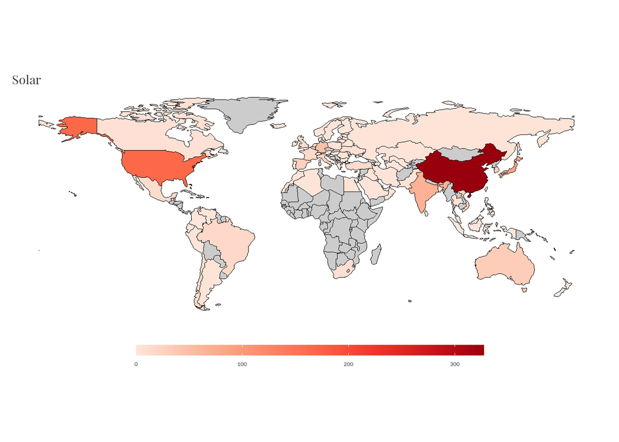

```r
# criando o mapa temático
owid_map(energia_solar)
```

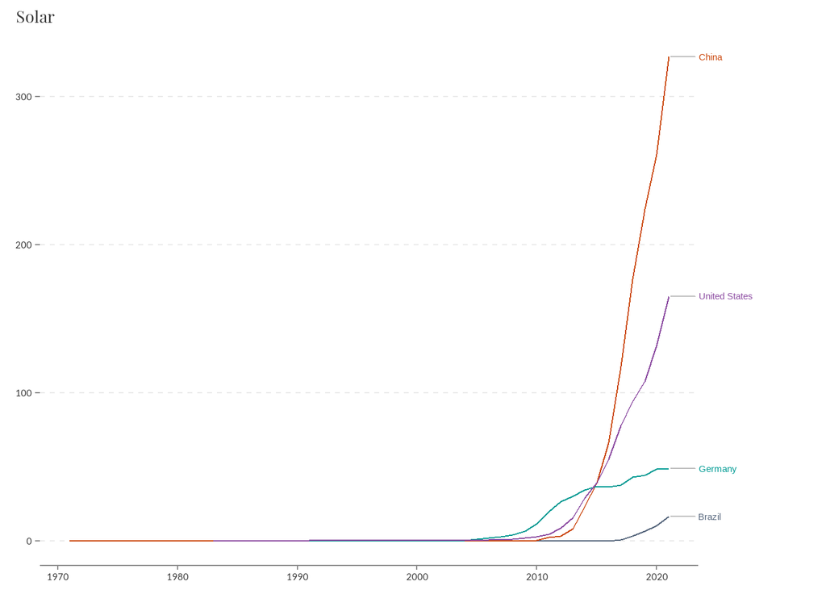

```r
owid_plot(energia_solar, summarise = FALSE, filter = c("Brazil", "Germany",
                                                       "United States", "China"))
```